# Project Proposal

Roy Paz, Tzahi Katz, Noam Munz

## 1. Introduction

In the last two decades the quality of air in our living spaces has declined following a rampant increase in production and manufacturing due to rising of global consumerism. In this project we will research whether the quality of air has an immediate effect on health outcomes among pregnant women and infants.

This type of research will help determine if and how society can change its production and manufacturing methods in order to improve health among it’s members.

In the recent years both volume and affect of mass production and standards of tracking and storing data have increased which in turn provides an accessible information with critical importance to be explored.

## 2. Data

We will use three data sets to research the topic.

**Air quality data:**  
a data set detailing the air quality in the United States in 2003-2020.  
Data are available by state and year. The set contains:  
- different types of chemical compounds and their prevalence in the air.  
- an Index that indicates the quality of air, denoted by AQI.  
- count of days in respect to varying levels of air quality.  
Further information about the data dimensions and source can be found in the README appendix.

**Infant birth data:**  
a data set detailing birth and fertility information in the United States in 2007-2020.  
Data are available by state, year of birth and variety of statistical information regarding infant measurements.  
The data contains:  
- Number of births and fertility rates.  
- Division of cases by mothers age.  
- weight and other information regarding the distribution of weight by different categories.  
Further information about the data dimensions and source can be found in the README appendix.

**Infant death data:**  
a data set detailing, births, health complications, deaths, and causes of deaths among babies under 1 year of age as well as their mothers in the United States in 2007-2019.  
The data contains:  
- Division of cases by mothers age  
- Chapter code which indicates the health complication / cause of death.  
- number of deaths in proportion to the number of births.  
Further information about the data dimensions and source can be found in the README appendix.

## 3. Preliminary results

#### Plot No. 1

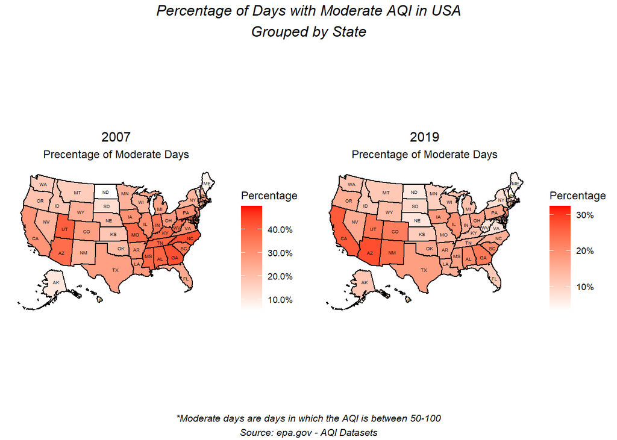

In the above plot you can see how different states are affected by air pollution in 2007 and how it shifted through the years to 2019. In some states it changed for the better and in some for the worse.  
Exploring health, mortality and morbidity outcomes in different states in those years can help us gain insight and determine if a correlation exists between the air quality and forementioned outcomes and analyze what factors are influencing the correlation the most.

#### Plot No. 2

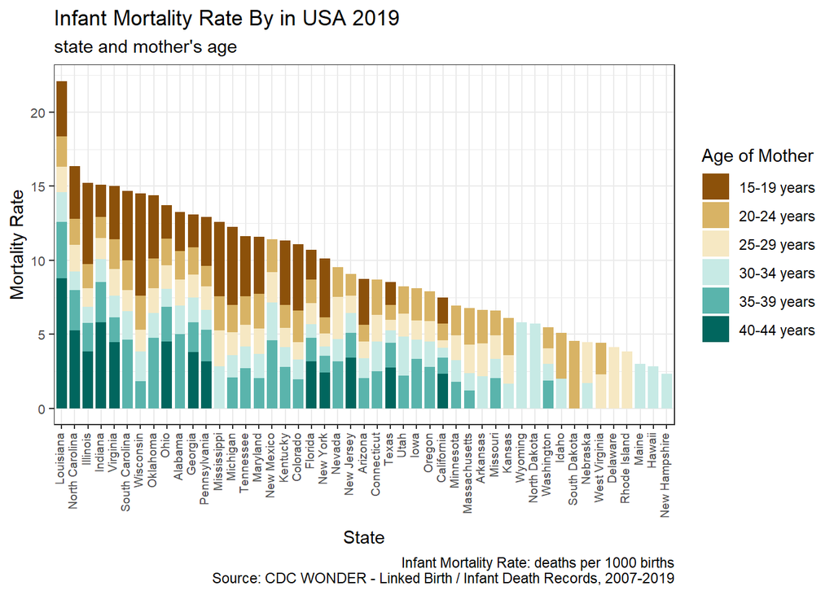

This graph details the death rate by country and age of mother (range). these results can be directly compared to the states AQI to test correlation. but further analyzing will be needed for any meaningful interpretation.  
Also, it is immediately visible that there is a correlation between infant’s death rate and the mother’s age when giving birth - the youngest and oldest age groups make a sizable proportion of the overall deaths. furthermore, in states with low death rates it seems that almost none of the deaths are from women belonging to groups 15-19 and 40-44.

#### Plot No. 3

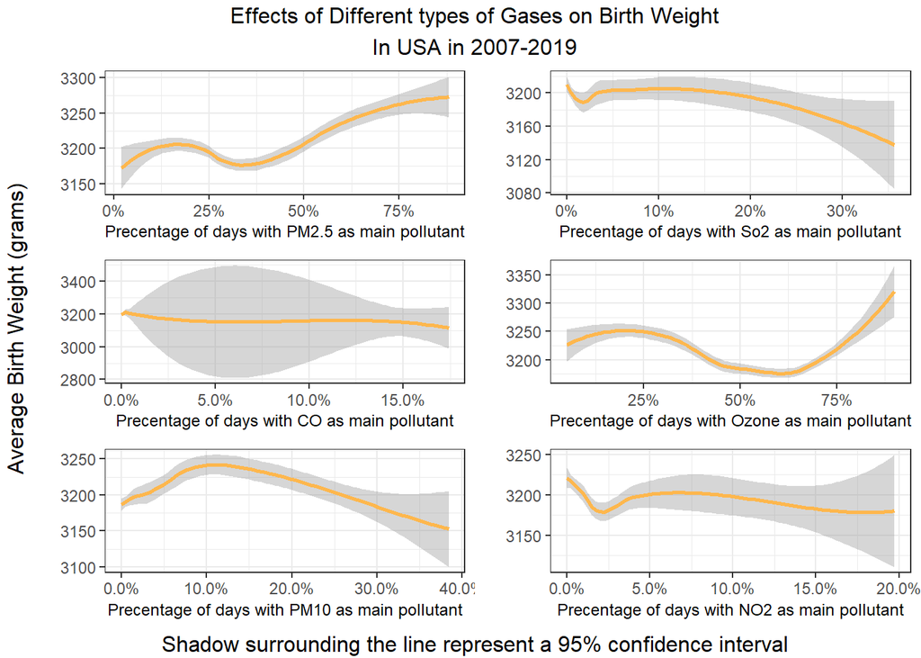

This plot demonstrates a correlation between the prevalence of different types of gases to the birth weight of infants.  
Although all averages seem to be considered healthy weights for newborns, there seems to be a trend for some gases like So2 and PM2.5.  
Exploring Morbidity in infants and how it relates to weight could grant us vital information in regards to the affects of air quality on infant’s health.

## 4. Data analysis plan

To answer our research question we will use air quality data (explanatory, X) to explore correlating health outcomes in infants and pregnant women (response, Y). results in different states and different years will be used as comparison groups.

To answer our question we will use data visualization and data manipulation methods such as plotting, mutating, pivoting, building statistical models, and interpreting the results.

**Team Work**  
The work will be divided into 5 main tasks:  
- Researching the topic and collecting data.  
- Tidying the data to a workable state.  
- Manipulating the data to fit visualization needs.  
- Visualizing relations between Data points.  
- Reviewing the project

Each task will be done by one or two members of the team and then corresponded to the rest.  
Reviewing will be done by the entire team.

## Appendix

### Data README

```
# SISE2601 Project data description
================
Team Members: Roy Paz, Tzahi Katz, Noam Munz
#################################################################################################################

### Air Quality Data: [976 x 18]

Year: The year of the sampled data
_________________________________________________________________________________________________________________
State:: The state in which the data was collected.
_________________________________________________________________________________________________________________
Days with AQI: Number of days in the year having an Air Quality Index value. This is the number of days on which measurements from any monitoring site in the state were reported to the database.
_________________________________________________________________________________________________________________
Good Days: Number of days in the year having an AQI value 0 through 50.

_________________________________________________________________________________________________________________
Moderate Days: Number of days in the year having and AQI value 51 through 100.
_________________________________________________________________________________________________________________
Unhealthy for Sensitive Groups Days: Number of days in the year having an AQI value 101 through 150.
_________________________________________________________________________________________________________________
Unhealthy Days: Number of days in the year having an AQI value 151 through 200.
_________________________________________________________________________________________________________________
Very Unhealthy Days: Number of days in the year having an AQI value 201 through 300.
_________________________________________________________________________________________________________________
Hazardous Days: Number of days in the year having an AQI value 301 or higher.  Note: The official AQI hazardous category range is 301-500.  Values above 500 are considered â€œBeyond the AQIâ€ and are included in the # Days Hazardous in this report.
_________________________________________________________________________________________________________________
Max AQI: The highest daily AQI value in the year.
_________________________________________________________________________________________________________________
90th Percentile AQI: 90 percent of daily AQI values during the year were less than or equal to the 90th percentile value.
_________________________________________________________________________________________________________________
Median AQI: Half of daily AQI values during the year were less than or equal to the median value, and half equaled or exceeded it
_________________________________________________________________________________________________________________
Days CO: Days in which CO was the main pollutant. range from 0 to 500.
_________________________________________________________________________________________________________________
Days NO2: Days in which NO2 was the main pollutant. ranges from 0 to 500.
_________________________________________________________________________________________________________________
Days Ozone: Days in which Ozone was the main pollutant. ranges from 0 to 500.
_________________________________________________________________________________________________________________
Days SO2: Days in which SO2 was the main pollutant. ranges from 0 to 500.
_________________________________________________________________________________________________________________
```

[output cut: 41 more lines]

```
_________________________________________________________________________________________________________________
State: The state in which the data was collected.
_________________________________________________________________________________________________________________
Year of Death: The state in which the data was collected.
_________________________________________________________________________________________________________________
Age of Mother: division of the data by mother's age in years (grouped).
_________________________________________________________________________________________________________________
ICD Chapter: a code that represents the health complication / cause of death. a map to all ICD-10 codes can be found [here](https://www.icd10data.com/ICD10CM/Codes).
_________________________________________________________________________________________________________________
Deaths: Number of total deaths.
_________________________________________________________________________________________________________________
Births: Number of total births.
_________________________________________________________________________________________________________________
Death Rate: Number of expected deaths per 1000 births. (deaths divided by births multiplied by 1000).
_________________________________________________________________________________________________________________
```

```
# SISE2601 Project data description
================
Team Members: Roy Paz, Tzahi Katz, Noam Munz
#################################################################################################################

Below are sources for the data used in this proposal

- Air quality datasets:
https://aqs.epa.gov/aqsweb/airdata/download_files.html#AQI

- Infant deaths datasets:
https://wonder.cdc.gov/controller/datarequest/D69;jsessionid=6DE2DADD3E76C8342ED48F9D1ACC

- births (natality) datasets:
https://wonder.cdc.gov/controller/datarequest/D66
```

### Source code

```r
library(knitr)
library(tidyverse)
library(broom)
library(htmltools)
library(dplyr)
library(gridExtra)
library(tidyverse)
library(usmap)
library(ggplot2)
library(gtable)
library(echarts4r)
library(gapminder)
library(echarts4r.maps)
library(grid)
opts_chunk$set(echo=FALSE) # hide source code in the document
# loading data
AQI_data = read.csv(file = 'C:\\Users\\roy1p\\PycharmProjects\\BGU python\\Advanced Programming project\\Final Data\\air quality\\aqi_by_State_2003-2020.csv')
birth_data = read.csv(file = "C:\\Users\\roy1p\\PycharmProjects\\BGU python\\Advanced Programming project\\Final Data\\Infant Birth\\Infant_Birth_2007-2020.csv")
death_data = read.csv(file ="C:\\Users\\roy1p\\PycharmProjects\\BGU python\\Advanced Programming project\\Final Data\\Infant Death\\Infant_Death_2007-2019.csv")

# filter only 2007-2019 from the data
AQI_data = AQI_data %>% filter(Year <= 2019 & Year >= 2007)
birth_data = birth_data %>% filter(Year <= 2019 & Year >= 2007)
birth_data["State"][birth_data["State"] == "District of Columbia"] <- "District Of Columbia"

# normalizing air quality days count in proportion to number of days sampled
AQI_data$Good.Days = with(AQI_data,Good.Days/Days.with.AQI)
AQI_data$Moderate.Days = with(AQI_data,Moderate.Days/Days.with.AQI)
AQI_data$Unhealthy.for.Sensitive.Groups.Days = with(AQI_data,Unhealthy.for.Sensitive.Groups.Days/Days.with.AQI)
AQI_data$Unhealthy.Days = with(AQI_data,Unhealthy.Days/Days.with.AQI)
AQI_data$Very.Unhealthy.Days = with(AQI_data,Very.Unhealthy.Days/Days.with.AQI)
AQI_data$Hazardous.Days = with(AQI_data,Hazardous.Days/Days.with.AQI)
AQI_data$X90th.Percentile.AQI = with(AQI_data,X90th.Percentile.AQI/Days.with.AQI)
AQI_data$Median.AQI = with(AQI_data,Median.AQI/Days.with.AQI)
AQI_data$Days.CO = with(AQI_data,Days.CO/Days.with.AQI)
AQI_data$Days.NO2 = with(AQI_data,Days.NO2/Days.with.AQI)
AQI_data$Days.Ozone = with(AQI_data,Days.Ozone/Days.with.AQI)
AQI_data$Days.SO2 = with(AQI_data,Days.SO2/Days.with.AQI)
AQI_data$Days.PM2.5 = with(AQI_data,Days.PM2.5/Days.with.AQI)
AQI_data$Days.PM10 = with(AQI_data,Days.PM10/Days.with.AQI)

# fixing death rate column
for (i in 1:nrow(death_data)) {
  death_data[i,12] = (gsub("\\(Unreliable\\)", "", death_data[i,12]))
}
death_data <- transform(death_data, Death.Rate = as.numeric(Death.Rate))
# figure No. 1
colnames(AQI_data)[which(names(AQI_data) == "State")] <- "state"
AQI_data2019 = AQI_data %>% filter(Year == 2019)
AQI_data2007 = AQI_data %>% filter(Year == 2007)

map2019 = plot_usmap(data = AQI_data2019, values = "Moderate.Days", color = "Black", labels = TRUE, )+
  labs(title = "2019", subtitle = "Precentage of Moderate Days") +
  scale_fill_continuous(
    low = "white", high = "red", name = "Percentage", label = scales::percent) +
  theme(legend.position = "right")+ theme(plot.title = element_text(hjust = 0.5), plot.subtitle = element_text(hjust=0.5))
map2019$layers[[2]]$aes_params$size <- 1.3

map2007 = plot_usmap(data = AQI_data2007, values = "Moderate.Days", color = "Black", labels = TRUE, )+
  labs(title = "2007", subtitle = "Precentage of Moderate Days") +
  scale_fill_continuous(
    low = "white", high = "red", name = "Percentage", label = scales::percent
  ) +
  theme(legend.position = "right") + theme(plot.title = element_text(hjust = 0.5), plot.subtitle = element_text(hjust=0.5))
map2007$layers[[2]]$aes_params$size <- 1.3

grid.arrange(map2007, map2019,nrow = 1, top=textGrob("Percentage of Days with Moderate AQI in USA\nGrouped by State", gp=
gpar(fontsize=12, font=3)), bottom = textGrob("*Moderate days are days in which the AQI is between 50-100\nSource: epa.gov - AQI Datasets", gp=gpar(fontsize=8, font=3)))
colnames(AQI_data)[which(names(AQI_data) == "state")] <- "State"
death_data_grouped_age = death_data %>% group_by(State, Year.of.Death, Age.of.Mother) %>% summarise_at(vars("Death.Rate"),mean)

death_data_2019 = death_data_grouped_age %>% filter(Year.of.Death == 2019)

ggplot(death_data_2019, aes(x= reorder(State, -Death.Rate,sum), y= Death.Rate))+
  geom_col(width = 0.8, aes(fill= Age.of.Mother))+
  labs(title="Infant Mortality Rate By in USA 2019", subtitle = "state and mother's age",x= "State", y = "Mortality Rate", caption= "Infant Mortality Rate: deaths per 1000 births\nSource: CDC WONDER - Linked Birth / Infant Death Records, 2007-2019",fill = "Age of Mother")+
  theme_bw()+
  theme(axis.text.x = element_text(angle = 90, vjust = 0.2, hjust=1, size= 7),
        axis.text.y = element_text(size= 8),
        axis.title.x = element_text(margin = unit(c(3, 0, 0, 0), "mm")),
        panel.border=element_rect(fill=NA))+ scale_fill_brewer(palette = "BrBG")
#''' group by the tables '''
grouped_birth_data = data.frame(birth_data["Year"],birth_data["State"], birth_data["Age.of.Mother.10"],birth_data["Average.Birth.Weight"],birth_data["Standard.Deviation.for.Average.Birth.Weight"])
grouped_birth_data = grouped_birth_data %>% group_by(Year,State) %>% summarise_at(vars('Average.Birth.Weight',"Standard.Deviation.for.Average.Birth.Weight"),mean)

#''' remove unmatch States '''
AQI_data = AQI_data %>% filter(State != "Country Of Mexico", State != "Puerto Rico", State != "Virgin Islands")

# ''' make one data frame for AQI table and Birth table'''
wei_gas_data = data.frame(AQI_data["Year"], AQI_data["State"], AQI_data["Days.PM2.5"], AQI_data["Days.SO2"], AQI_data["Days.CO"], AQI_data["Days.PM10"], AQI_data["Days.NO2"], AQI_data["Days.Ozone"], grouped_birth_data["Average.Birth.Weight"], grouped_birth_data["Standard.Deviation.for.Average.Birth.Weight"])


# plot from here
graph_SO2 = ggplot(wei_gas_data,aes(x = Days.SO2))+
  geom_smooth(aes(y = Average.Birth.Weight), color="#FFB74D")+
  theme_bw()+
  scale_x_continuous(labels = scales::percent)+
  labs(x="Precentage of days with So2 as main pollutant", y = "")+
  theme(axis.title = element_text(size = 9))


graph_PM2.5 = ggplot(wei_gas_data,aes(x = Days.PM2.5))+
  geom_smooth(aes(y = Average.Birth.Weight), color="#FFB74D")+
    theme_bw()+
  scale_x_continuous(labels = scales::percent)+
  labs(x="Precentage of days with PM2.5 as main pollutant", y = "")+
  theme(axis.title = element_text(size = 9))


graph_PM10 = ggplot(wei_gas_data,aes(x = Days.PM10))+
  geom_smooth(aes(y = Average.Birth.Weight), color="#FFB74D")+
    theme_bw()+
  scale_x_continuous(labels = scales::percent)+
  labs(x="Precentage of days with PM10 as main pollutant", y = "")+
  theme(axis.title = element_text(size = 9))


graph_OZONE = ggplot(wei_gas_data,aes(x = Days.Ozone))+
  geom_smooth(aes(y = Average.Birth.Weight), color="#FFB74D")+
    theme_bw()+
  scale_x_continuous(labels = scales::percent)+
  labs(x="Precentage of days with Ozone as main pollutant", y = "")+
  theme(axis.title = element_text(size = 9))


graph_NO2 = ggplot(wei_gas_data,aes(x = Days.NO2))+
  geom_smooth(aes(y = Average.Birth.Weight), color="#FFB74D")+
    theme_bw()+
  scale_x_continuous(labels = scales::percent)+
  labs(x="Precentage of days with NO2 as main pollutant", y = "")+
  theme(axis.title = element_text(size = 9))

graph_CO = ggplot(wei_gas_data,aes(x = Days.CO))+
  geom_smooth(aes(y = Average.Birth.Weight), color="#FFB74D")+
  theme_bw()+
  scale_x_continuous(labels = scales::percent)+
  labs(x="Precentage of days with CO as main pollutant", y = "")+
  theme(axis.title = element_text(size = 9))

grid.arrange(graph_PM2.5, graph_SO2, graph_CO,graph_OZONE,graph_PM10, graph_NO2, ncol=2, top="Effects of Different types of Gases on Birth Weight\nIn USA in 2007-2019", left="Average Birth Weight (grams)", bottom= "Shadow surrounding the line represent a 95% confidence interval")
cat(readLines('C:\\Users\\roy1p\\OneDrive - post.bgu.ac.il\\Desktop\\Coding\\R projects\\Advanced data analysis in R\\Final Proj\\Final Data\\README.md'), sep = '\n')
cat(readLines('C:\\Users\\roy1p\\OneDrive - post.bgu.ac.il\\Desktop\\Coding\\R projects\\Advanced data analysis in R\\Final Proj\\Final Data\\sources.md'), sep = '\n')
```